# DESCRIPTION

The dataset provided contains movie reviews given by Amazon customers. Reviews were given between May 1996 and July 2014.

Data Dictionary UserID – 4848 customers who provided a rating for each movie Movie 1 to Movie 206 – 206 movies for which ratings are provided by 4848 distinct users

Data Considerations

- All the users have not watched all the movies and therefore, all movies are not rated. These missing values are represented by NA.
- Ratings are on a scale of -1 to 10 where -1 is the least rating and 10 is the best.

# Analysis Task

Exploratory Data Analysis:

1. Which movies have maximum views/ratings?
2. What is the average rating for each movie? Define the top 5 movies with the maximum ratings.
3. Define the top 5 movies with the least audience.

```python
!pip install scikit-surprise
```

```python
# Importing required packages

import numpy as np
import pandas as pd
import re                              # Regular Expressions
import matplotlib.pyplot as plt
import seaborn as sns
%matplotlib inline
import surprise                        # Surprise is a Python scikit for building and analyzing recommender systems that deal with explicit rating data.
```

```python
RS = pd.read_csv('Amazon - Movies and TV Ratings.csv')
```

```python
RS.head()
```

|  | user_id | Movie1 | Movie2 | Movie3 | Movie4 | Movie5 | Movie6 | Movie7 | Movie8 | Movie9 | ... | Movie197 | Movie198 | Movie199 | Movie200 | Movie201 | Movie202 | Movie203 | Movie204 | Movie205 | Movie206 |
| --- | --- | --- | --- | --- | --- | --- | --- | --- | --- | --- | --- | --- | --- | --- | --- | --- | --- | --- | --- | --- | --- |
| 0 | A3R5OBKS7OM2IR | 5.0 | 5.0 | NaN | NaN | NaN | NaN | NaN | NaN | NaN | ... | NaN | NaN | NaN | NaN | NaN | NaN | NaN | NaN | NaN | NaN |
| 1 | AH3QC2PC1VTGP | NaN | NaN | 2.0 | NaN | NaN | NaN | NaN | NaN | NaN | ... | NaN | NaN | NaN | NaN | NaN | NaN | NaN | NaN | NaN | NaN |
| 2 | A3LKP6WPMP9UKX | NaN | NaN | NaN | 5.0 | NaN | NaN | NaN | NaN | NaN | ... | NaN | NaN | NaN | NaN | NaN | NaN | NaN | NaN | NaN | NaN |
| 3 | AVIY68KEPQ5ZD | NaN | NaN | NaN | 5.0 | NaN | NaN | NaN | NaN | NaN | ... | NaN | NaN | NaN | NaN | NaN | NaN | NaN | NaN | NaN | NaN |
| 4 | A1CV1WROP5KTTW | NaN | NaN | NaN | NaN | 5.0 | NaN | NaN | NaN | NaN | ... | NaN | NaN | NaN | NaN | NaN | NaN | NaN | NaN | NaN | NaN |

5 rows × 207 columns

```python
RS.info()
```

```
<class 'pandas.core.frame.DataFrame'>
RangeIndex: 4848 entries, 0 to 4847
Columns: 207 entries, user_id to Movie206
dtypes: float64(206), object(1)
memory usage: 7.7+ MB
```

```python
RS.size
```

```
1003536
```

```python
RS.shape
```

```
(4848, 207)
```

```python
RS.describe().T
```

|  | count | mean | std | min | 25% | 50% | 75% | max |
| --- | --- | --- | --- | --- | --- | --- | --- | --- |
| Movie1 | 1.0 | 5.000000 | NaN | 5.0 | 5.00 | 5.0 | 5.0 | 5.0 |
| Movie2 | 1.0 | 5.000000 | NaN | 5.0 | 5.00 | 5.0 | 5.0 | 5.0 |
| Movie3 | 1.0 | 2.000000 | NaN | 2.0 | 2.00 | 2.0 | 2.0 | 2.0 |
| Movie4 | 2.0 | 5.000000 | 0.000000 | 5.0 | 5.00 | 5.0 | 5.0 | 5.0 |
| Movie5 | 29.0 | 4.103448 | 1.496301 | 1.0 | 4.00 | 5.0 | 5.0 | 5.0 |
| ... | ... | ... | ... | ... | ... | ... | ... | ... |
| Movie202 | 6.0 | 4.333333 | 1.632993 | 1.0 | 5.00 | 5.0 | 5.0 | 5.0 |
| Movie203 | 1.0 | 3.000000 | NaN | 3.0 | 3.00 | 3.0 | 3.0 | 3.0 |
| Movie204 | 8.0 | 4.375000 | 1.407886 | 1.0 | 4.75 | 5.0 | 5.0 | 5.0 |
| Movie205 | 35.0 | 4.628571 | 0.910259 | 1.0 | 5.00 | 5.0 | 5.0 | 5.0 |
| Movie206 | 13.0 | 4.923077 | 0.277350 | 4.0 | 5.00 | 5.0 | 5.0 | 5.0 |

206 rows × 8 columns

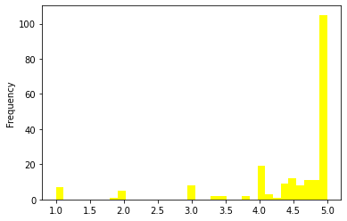

```python
# to plot the mean frequency
RS.describe().T['mean'].plot(bins=35, kind='hist', color = 'yellow')
```

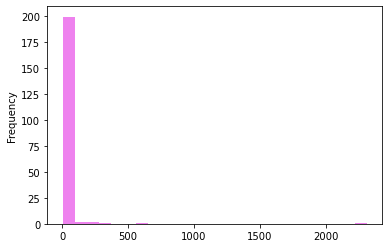

```python
# to plot the count frequency
RS.describe().T['count'].plot(bins=25, kind='hist', color = 'violet')
```

# 1. Which movies have maximum views/ratings?

```python
# Let's find the movie with maximum ratings

RS.drop('user_id', axis=1).sum().sort_values(ascending = False)[:1].to_frame()
```

|  | 0 |
| --- | --- |
| Movie127 | 9511.0 |

```python
# Let's find the movie with maximum views

RS.describe().T['count'].sort_values(ascending= False)[:1].to_frame()
```

|  | count |
| --- | --- |
| Movie127 | 2313.0 |

```python
RS.index
```

```
RangeIndex(start=0, stop=4848, step=1)
```

```python
RS.columns
```

```
Index(['user_id', 'Movie1', 'Movie2', 'Movie3', 'Movie4', 'Movie5', 'Movie6',
       'Movie7', 'Movie8', 'Movie9',
       ...
       'Movie197', 'Movie198', 'Movie199', 'Movie200', 'Movie201', 'Movie202',
       'Movie203', 'Movie204', 'Movie205', 'Movie206'],
      dtype='object', length=207)
```

```python
RS_filtered =  RS.fillna(value=0)
RS_filtered
```

|  | user_id | Movie1 | Movie2 | Movie3 | Movie4 | Movie5 | Movie6 | Movie7 | Movie8 | Movie9 | ... | Movie197 | Movie198 | Movie199 | Movie200 | Movie201 | Movie202 | Movie203 | Movie204 | Movie205 | Movie206 |
| --- | --- | --- | --- | --- | --- | --- | --- | --- | --- | --- | --- | --- | --- | --- | --- | --- | --- | --- | --- | --- | --- |
| 0 | A3R5OBKS7OM2IR | 5.0 | 5.0 | 0.0 | 0.0 | 0.0 | 0.0 | 0.0 | 0.0 | 0.0 | ... | 0.0 | 0.0 | 0.0 | 0.0 | 0.0 | 0.0 | 0.0 | 0.0 | 0.0 | 0.0 |
| 1 | AH3QC2PC1VTGP | 0.0 | 0.0 | 2.0 | 0.0 | 0.0 | 0.0 | 0.0 | 0.0 | 0.0 | ... | 0.0 | 0.0 | 0.0 | 0.0 | 0.0 | 0.0 | 0.0 | 0.0 | 0.0 | 0.0 |
| 2 | A3LKP6WPMP9UKX | 0.0 | 0.0 | 0.0 | 5.0 | 0.0 | 0.0 | 0.0 | 0.0 | 0.0 | ... | 0.0 | 0.0 | 0.0 | 0.0 | 0.0 | 0.0 | 0.0 | 0.0 | 0.0 | 0.0 |
| 3 | AVIY68KEPQ5ZD | 0.0 | 0.0 | 0.0 | 5.0 | 0.0 | 0.0 | 0.0 | 0.0 | 0.0 | ... | 0.0 | 0.0 | 0.0 | 0.0 | 0.0 | 0.0 | 0.0 | 0.0 | 0.0 | 0.0 |
| 4 | A1CV1WROP5KTTW | 0.0 | 0.0 | 0.0 | 0.0 | 5.0 | 0.0 | 0.0 | 0.0 | 0.0 | ... | 0.0 | 0.0 | 0.0 | 0.0 | 0.0 | 0.0 | 0.0 | 0.0 | 0.0 | 0.0 |
| ... | ... | ... | ... | ... | ... | ... | ... | ... | ... | ... | ... | ... | ... | ... | ... | ... | ... | ... | ... | ... | ... |
| 4843 | A1IMQ9WMFYKWH5 | 0.0 | 0.0 | 0.0 | 0.0 | 0.0 | 0.0 | 0.0 | 0.0 | 0.0 | ... | 0.0 | 0.0 | 0.0 | 0.0 | 0.0 | 0.0 | 0.0 | 0.0 | 0.0 | 5.0 |
| 4844 | A1KLIKPUF5E88I | 0.0 | 0.0 | 0.0 | 0.0 | 0.0 | 0.0 | 0.0 | 0.0 | 0.0 | ... | 0.0 | 0.0 | 0.0 | 0.0 | 0.0 | 0.0 | 0.0 | 0.0 | 0.0 | 5.0 |
| 4845 | A5HG6WFZLO10D | 0.0 | 0.0 | 0.0 | 0.0 | 0.0 | 0.0 | 0.0 | 0.0 | 0.0 | ... | 0.0 | 0.0 | 0.0 | 0.0 | 0.0 | 0.0 | 0.0 | 0.0 | 0.0 | 5.0 |
| 4846 | A3UU690TWXCG1X | 0.0 | 0.0 | 0.0 | 0.0 | 0.0 | 0.0 | 0.0 | 0.0 | 0.0 | ... | 0.0 | 0.0 | 0.0 | 0.0 | 0.0 | 0.0 | 0.0 | 0.0 | 0.0 | 5.0 |
| 4847 | AI4J762YI6S06 | 0.0 | 0.0 | 0.0 | 0.0 | 0.0 | 0.0 | 0.0 | 0.0 | 0.0 | ... | 0.0 | 0.0 | 0.0 | 0.0 | 0.0 | 0.0 | 0.0 | 0.0 | 0.0 | 5.0 |

4848 rows × 207 columns

```python
RS_filtered1 =RS_filtered.drop(columns = 'user_id')
RS_filtered1.head()
```

|  | Movie1 | Movie2 | Movie3 | Movie4 | Movie5 | Movie6 | Movie7 | Movie8 | Movie9 | Movie10 | ... | Movie197 | Movie198 | Movie199 | Movie200 | Movie201 | Movie202 | Movie203 | Movie204 | Movie205 | Movie206 |
| --- | --- | --- | --- | --- | --- | --- | --- | --- | --- | --- | --- | --- | --- | --- | --- | --- | --- | --- | --- | --- | --- |
| 0 | 5.0 | 5.0 | 0.0 | 0.0 | 0.0 | 0.0 | 0.0 | 0.0 | 0.0 | 0.0 | ... | 0.0 | 0.0 | 0.0 | 0.0 | 0.0 | 0.0 | 0.0 | 0.0 | 0.0 | 0.0 |
| 1 | 0.0 | 0.0 | 2.0 | 0.0 | 0.0 | 0.0 | 0.0 | 0.0 | 0.0 | 0.0 | ... | 0.0 | 0.0 | 0.0 | 0.0 | 0.0 | 0.0 | 0.0 | 0.0 | 0.0 | 0.0 |
| 2 | 0.0 | 0.0 | 0.0 | 5.0 | 0.0 | 0.0 | 0.0 | 0.0 | 0.0 | 0.0 | ... | 0.0 | 0.0 | 0.0 | 0.0 | 0.0 | 0.0 | 0.0 | 0.0 | 0.0 | 0.0 |
| 3 | 0.0 | 0.0 | 0.0 | 5.0 | 0.0 | 0.0 | 0.0 | 0.0 | 0.0 | 0.0 | ... | 0.0 | 0.0 | 0.0 | 0.0 | 0.0 | 0.0 | 0.0 | 0.0 | 0.0 | 0.0 |
| 4 | 0.0 | 0.0 | 0.0 | 0.0 | 5.0 | 0.0 | 0.0 | 0.0 | 0.0 | 0.0 | ... | 0.0 | 0.0 | 0.0 | 0.0 | 0.0 | 0.0 | 0.0 | 0.0 | 0.0 | 0.0 |

5 rows × 206 columns

```python
RS_filtered1.shape
```

```
(4848, 206)
```

```python
RS_filtered.describe()
```

|  | Movie1 | Movie2 | Movie3 | Movie4 | Movie5 | Movie6 | Movie7 | Movie8 | Movie9 | Movie10 | ... | Movie197 | Movie198 | Movie199 | Movie200 | Movie201 | Movie202 | Movie203 | Movie204 | Movie205 | Movie206 |
| --- | --- | --- | --- | --- | --- | --- | --- | --- | --- | --- | --- | --- | --- | --- | --- | --- | --- | --- | --- | --- | --- |
| count | 4848.000000 | 4848.000000 | 4848.000000 | 4848.000000 | 4848.000000 | 4848.000000 | 4848.000000 | 4848.000000 | 4848.000000 | 4848.000000 | ... | 4848.000000 | 4848.000000 | 4848.000000 | 4848.000000 | 4848.000000 | 4848.000000 | 4848.000000 | 4848.000000 | 4848.000000 | 4848.000000 |
| mean | 0.001031 | 0.001031 | 0.000413 | 0.002063 | 0.024546 | 0.000825 | 0.001031 | 0.001031 | 0.001031 | 0.001031 | ... | 0.003919 | 0.002063 | 0.001031 | 0.007632 | 0.002682 | 0.005363 | 0.000619 | 0.007219 | 0.033416 | 0.013201 |
| std | 0.071811 | 0.071811 | 0.028724 | 0.101545 | 0.336268 | 0.057448 | 0.071811 | 0.071811 | 0.071811 | 0.071811 | ... | 0.130800 | 0.101545 | 0.071811 | 0.188769 | 0.110296 | 0.161142 | 0.043086 | 0.185478 | 0.399243 | 0.254991 |
| min | 0.000000 | 0.000000 | 0.000000 | 0.000000 | 0.000000 | 0.000000 | 0.000000 | 0.000000 | 0.000000 | 0.000000 | ... | 0.000000 | 0.000000 | 0.000000 | 0.000000 | 0.000000 | 0.000000 | 0.000000 | 0.000000 | 0.000000 | 0.000000 |
| 25% | 0.000000 | 0.000000 | 0.000000 | 0.000000 | 0.000000 | 0.000000 | 0.000000 | 0.000000 | 0.000000 | 0.000000 | ... | 0.000000 | 0.000000 | 0.000000 | 0.000000 | 0.000000 | 0.000000 | 0.000000 | 0.000000 | 0.000000 | 0.000000 |
| 50% | 0.000000 | 0.000000 | 0.000000 | 0.000000 | 0.000000 | 0.000000 | 0.000000 | 0.000000 | 0.000000 | 0.000000 | ... | 0.000000 | 0.000000 | 0.000000 | 0.000000 | 0.000000 | 0.000000 | 0.000000 | 0.000000 | 0.000000 | 0.000000 |
| 75% | 0.000000 | 0.000000 | 0.000000 | 0.000000 | 0.000000 | 0.000000 | 0.000000 | 0.000000 | 0.000000 | 0.000000 | ... | 0.000000 | 0.000000 | 0.000000 | 0.000000 | 0.000000 | 0.000000 | 0.000000 | 0.000000 | 0.000000 | 0.000000 |
| max | 5.000000 | 5.000000 | 2.000000 | 5.000000 | 5.000000 | 4.000000 | 5.000000 | 5.000000 | 5.000000 | 5.000000 | ... | 5.000000 | 5.000000 | 5.000000 | 5.000000 | 5.000000 | 5.000000 | 3.000000 | 5.000000 | 5.000000 | 5.000000 |

8 rows × 206 columns

```python
RS_max_views = RS_filtered1.sum()
RS_max_views
```

```
Movie1        5.0
Movie2        5.0
Movie3        2.0
Movie4       10.0
Movie5      119.0
            ...
Movie202     26.0
Movie203      3.0
Movie204     35.0
Movie205    162.0
Movie206     64.0
Length: 206, dtype: float64
```

```python
# let's find the max sum of ratings

max(RS_max_views)
```

```
9511.0
```

```python
RS_max_views.head()
RS_max_views.tail()
```

```
Movie202     26.0
Movie203      3.0
Movie204     35.0
Movie205    162.0
Movie206     64.0
dtype: float64
```

```python
RS_max_views.index
```

```
Index(['Movie1', 'Movie2', 'Movie3', 'Movie4', 'Movie5', 'Movie6', 'Movie7',
       'Movie8', 'Movie9', 'Movie10',
       ...
       'Movie197', 'Movie198', 'Movie199', 'Movie200', 'Movie201', 'Movie202',
       'Movie203', 'Movie204', 'Movie205', 'Movie206'],
      dtype='object', length=206)
```

```python
# Finding which movie has maximum veiws/Ratings

max_views = RS_max_views.argmax()
max_views
```

```
126
```

```python
# Verify if the movie has max views/ratings

RS_max_views['Movie126']
```

```
9.0
```

```python
sum(RS_max_views)
```

```
21928.0
```

# 2. What is the average rating for each movie? Define the top 5 movies with the maximum ratings.

```python
Avg_ratings_of_each_movie=sum(RS_max_views)/len(RS_max_views.index)
Avg_ratings_of_each_movie
```

```
106.44660194174757
```

```python
RS_df = pd.DataFrame(RS_max_views)
RS_df.head()
```

|  | 0 |
| --- | --- |
| Movie1 | 5.0 |
| Movie2 | 5.0 |
| Movie3 | 2.0 |
| Movie4 | 10.0 |
| Movie5 | 119.0 |

```python
RS_df.columns = ['rating']
```

```python
RS_df.index
```

```
Index(['Movie1', 'Movie2', 'Movie3', 'Movie4', 'Movie5', 'Movie6', 'Movie7',
       'Movie8', 'Movie9', 'Movie10',
       ...
       'Movie197', 'Movie198', 'Movie199', 'Movie200', 'Movie201', 'Movie202',
       'Movie203', 'Movie204', 'Movie205', 'Movie206'],
      dtype='object', length=206)
```

```python
RS_df.tail()
```

|  | rating |
| --- | --- |
| Movie202 | 26.0 |
| Movie203 | 3.0 |
| Movie204 | 35.0 |
| Movie205 | 162.0 |
| Movie206 | 64.0 |

```python
# The top 5 movies with the maximum ratings

RS_df.nlargest(5,'rating')
```

|  | rating |
| --- | --- |
| Movie127 | 9511.0 |
| Movie140 | 2794.0 |
| Movie16 | 1446.0 |
| Movie103 | 1241.0 |
| Movie29 | 1168.0 |

# 3. Define the top 5 movies with the least audience.

```python
#Top 5 movies having least audience

RS_df.nsmallest(5,'rating')
```

|  | rating |
| --- | --- |
| Movie45 | 1.0 |
| Movie58 | 1.0 |
| Movie60 | 1.0 |
| Movie67 | 1.0 |
| Movie69 | 1.0 |

```python
RS_melt = RS.melt(id_vars = RS.columns[0],value_vars=RS.columns[1:],var_name="Movies",value_name="Rating")
```

```python
RS_melt
```

|  | user_id | Movies | Rating |
| --- | --- | --- | --- |
| 0 | A3R5OBKS7OM2IR | Movie1 | 5.0 |
| 1 | AH3QC2PC1VTGP | Movie1 | NaN |
| 2 | A3LKP6WPMP9UKX | Movie1 | NaN |
| 3 | AVIY68KEPQ5ZD | Movie1 | NaN |
| 4 | A1CV1WROP5KTTW | Movie1 | NaN |
| ... | ... | ... | ... |
| 998683 | A1IMQ9WMFYKWH5 | Movie206 | 5.0 |
| 998684 | A1KLIKPUF5E88I | Movie206 | 5.0 |
| 998685 | A5HG6WFZLO10D | Movie206 | 5.0 |
| 998686 | A3UU690TWXCG1X | Movie206 | 5.0 |
| 998687 | AI4J762YI6S06 | Movie206 | 5.0 |

998688 rows × 3 columns

```python
RS_melt.shape
```

```
(998688, 3)
```

```python
melt_filtered = RS_melt.fillna(0)
melt_filtered.shape
```

```
(998688, 3)
```

Recommendation Model:

Some of the movies hadn’t been watched and therefore, are not rated by the users. Netflix would like to take this as an opportunity and build a machine learning recommendation algorithm which provides the ratings for each of the users.

1. Divide the data into training and test data
2. Build a recommendation model on training data
3. Make predictions on the test data

```python
import sklearn
```

```python
from sklearn.model_selection import train_test_split
```

```python
from surprise import Reader                 # Reader is used to parse a file containing ratings.
from surprise import accuracy
from surprise import Dataset
from surprise.model_selection import train_test_split
from surprise import SVD
from surprise.model_selection import cross_validate
```

```python
reader = Reader(rating_scale = (-1,10))
data = Dataset.load_from_df(RS_melt.fillna(0), reader=reader)
```

# 4. Divide the data into training and test data

```python
# Divide the data into training and test data

trainset, testset = train_test_split(data, test_size = 0.25)
```

```python
algo = SVD()
```

# 5. Building a recommendation model on training data

```python
# Building a recommendation model on training data

algo.fit(trainset)
```

```
<surprise.prediction_algorithms.matrix_factorization.SVD at 0x125d61df6d0>
```

# 6. Make predictions on the test data

```python
# Make predictions on the test data

predict = algo.test(testset)
```

```python
cross_validate(algo, data,measures = ['RMSE', 'MAE'], cv=3, verbose = True)
```

```
Evaluating RMSE, MAE of algorithm SVD on 3 split(s).

                  Fold 1  Fold 2  Fold 3  Mean    Std
RMSE (testset)    0.2807  0.2834  0.2806  0.2816  0.0013
MAE (testset)     0.0421  0.0424  0.0423  0.0423  0.0001
Fit time          37.82   38.05   40.95   38.94   1.42
Test time         2.88    3.05    3.14    3.02    0.11
```

```
{'test_rmse': array([0.2806774 , 0.28339754, 0.28058596]),
 'test_mae': array([0.04211452, 0.04244299, 0.04230825]),
 'fit_time': (37.82173728942871, 38.05062198638916, 40.94517540931702),
 'test_time': (2.8758606910705566, 3.0512828826904297, 3.138805866241455)}
```

```python
user_id = 'A3VCKTRD24BG7K'
Movie = 'Movie5'
rating = '5'
algo.predict(user_id, Movie, r_ui = rating)
print(cross_validate(algo, data, measures = ['RMSE', 'MAE'], cv = 3, verbose = True))
```

```
Evaluating RMSE, MAE of algorithm SVD on 3 split(s).

                  Fold 1  Fold 2  Fold 3  Mean    Std
RMSE (testset)    0.2823  0.2807  0.2816  0.2816  0.0007
MAE (testset)     0.0426  0.0427  0.0425  0.0426  0.0001
Fit time          40.22   41.55   40.71   40.83   0.55
Test time         3.09    2.93    2.91    2.98    0.08
{'test_rmse': array([0.28234486, 0.28070506, 0.28162503]), 'test_mae': array([0.04257032, 0.04268166, 0.04254181]), 'fit_time': (40.21530055999756, 41.55135774612427, 40.7111611366272), 'test_time': (3.0878255367279053, 2.9336977005004883, 2.914088249206543)}
```

From the above result through cross-validation, it can be observed the 'Fit Time' - (40.21530055999756, 41.55135774612427, 40.7111611366272) & 'test_time': (3.0878255367279053, 2.9336977005004883, 2.914088249206543)}

```python
def repeat(ml_type,dframe,min_,max_):
    rd = Reader()
    data = Dataset.load_from_df(dframe,reader=rd)
    print(cross_validate(ml_type, data, measures = ['RMSE', 'MAE'], cv = 3, verbose = True))
    print("#"*10)
    u_id = 'A2SWZDBR427H4'
    m_id = 'Movie16'
    ra_u = 4.0
    print(ml_type.predict(u_id, Movie, r_ui=ra_u,verbose=True))
    print("#"*10)
    print()
```

```python
amazon= RS.iloc[:3000, :50]
movie_data = amazon.melt(id_vars = amazon.columns[0],value_vars=amazon.columns[1:],var_name="Movies",value_name="Rating")
```

```python
repeat(SVD(),movie_data.fillna(0),-1,10)
repeat(SVD(),movie_data.fillna(movie_data.mean()),-1,10)
repeat(SVD(),movie_data.fillna(movie_data.median()),-1,10)
```

```
Evaluating RMSE, MAE of algorithm SVD on 3 split(s).

                  Fold 1  Fold 2  Fold 3  Mean    Std
RMSE (testset)    1.0316  1.0271  1.0286  1.0291  0.0019
MAE (testset)     1.0133  1.0116  1.0122  1.0124  0.0007
Fit time          6.02    5.87    5.83    5.91    0.08
Test time         0.62    0.30    0.62    0.52    0.15
{'test_rmse': array([1.03158853, 1.0271104 , 1.02855531]), 'test_mae': array([1.0133409 , 1.01160405, 1.01220867]), 'fit_time': (6.018045425415039, 5.869853973388672, 5.832690477371216), 'test_time': (0.6248528957366943, 0.29683613777160645, 0.6248631477355957)}
##########
user: A2SWZDBR427H4 item: Movie5     r_ui = 4.00   est = 1.00   {'was_impossible': False}
user: A2SWZDBR427H4 item: Movie5     r_ui = 4.00   est = 1.00   {'was_impossible': False}
##########
```

```
Evaluating RMSE, MAE of algorithm SVD on 3 split(s).

                  Fold 1  Fold 2  Fold 3  Mean    Std
RMSE (testset)    0.0584  0.0604  0.0515  0.0568  0.0038
MAE (testset)     0.0072  0.0071  0.0072  0.0072  0.0001
Fit time          6.04    5.95    5.99    5.99    0.04
Test time         0.29    0.30    0.30    0.29    0.00
{'test_rmse': array([0.05838821, 0.0603705 , 0.05150561]), 'test_mae': array([0.00720165, 0.00711114, 0.00724078]), 'fit_time': (6.040083408355713, 5.952449798583984, 5.988849401473999), 'test_time': (0.28734397888183594, 0.29680323600769043, 0.29680657386779785)}
##########
user: A2SWZDBR427H4 item: Movie5     r_ui = 4.00   est = 4.59   {'was_impossible': False}
user: A2SWZDBR427H4 item: Movie5     r_ui = 4.00   est = 4.59   {'was_impossible': False}
##########
```

```
Evaluating RMSE, MAE of algorithm SVD on 3 split(s).

                  Fold 1  Fold 2  Fold 3  Mean    Std
RMSE (testset)    0.0611  0.0644  0.0612  0.0622  0.0015
MAE (testset)     0.0056  0.0050  0.0052  0.0053  0.0002
Fit time          6.00    6.01    5.88    5.97    0.06
Test time         0.38    0.72    0.30    0.47    0.18
{'test_rmse': array([0.06107006, 0.06439353, 0.06124446]), 'test_mae': array([0.0056214 , 0.00504658, 0.00517581]), 'fit_time': (6.002695798873901, 6.013610124588013, 5.8794965744018555), 'test_time': (0.38091230392456055, 0.7185792922973633, 0.2968411445617676)}
##########
user: A2SWZDBR427H4 item: Movie5     r_ui = 4.00   est = 4.96   {'was_impossible': False}
user: A2SWZDBR427H4 item: Movie5     r_ui = 4.00   est = 4.96   {'was_impossible': False}
##########
```

Well, Cross-validation is there for rescue. You can see there's a steep decrease in the 'Fit_Time' & 'Test_Time'. Anyway, you can do better with hyperparameter tuning / optimization.

```python
#trying grid search and find optimum hyperparameter value for n_factors

from surprise.model_selection import GridSearchCV
```

```python
param_grid = {'n_epochs':[20,30],
             'lr_all':[0.005,0.001],
             'n_factors':[50,100]}
```

```python
gs = GridSearchCV(SVD,param_grid,measures=['rmse','mae'],cv=3)
gs.fit(data)
```

```python
gs.best_score
```

```
{'rmse': 0.2796775904378172, 'mae': 0.0410570068581227}
```

```python
print(gs.best_score["rmse"])
print(gs.best_params["rmse"])
```

```
0.2796775904378172
{'n_epochs': 30, 'lr_all': 0.005, 'n_factors': 50}
```

It is inferred that the Grid Search which is to optimize the tuning parameteres yielded the best_score is 0.2796775904378172